# Butte Creek

Sadie Gill, Mark Tompkins

July 1, 2019

## Floodplain Modeling Details

**Data Source:** [Central Valley Floodplain Evaluation and Delineation (CVFED) HEC-RAS hydraulic model](https://s3-us-west-2.amazonaws.com/cvpiahabitat-r-package/cvpia-sit-model-inputs/CombinedTM_IQAR_Final-FULL-REPORT_20140206.pdf)

### Fall Run

A 17.1 mile portion of the entire mapped rearing extent of 17.1 miles was modeled using Central Valley Floodplain Evaluation and Delineation (CVFED) HEC-RAS hydraulic model. Of the entire mapped rearing extent, 17.1 miles were classified as low gradient and 0 miles were classified as high gradient based on a geomorphic analysis. Floodplain area per unit length was determined for the modeled extent and applied to determine areas for the non-modeled extent. A scaling factor of 0.1 was applied to the area per unit length for the high gradient extent. No scaling factor was applied to the low gradient extent.

### Spring Run and Steelhead

A 17.1 mile portion of the entire mapped rearing extent of 31.7 miles was modeled using Central Valley Floodplain Evaluation and Delineation (CVFED) HEC-RAS hydraulic model. Of the entire mapped rearing extent, 17.1 miles were classified as low gradient and 14.5 miles were classified as high gradient based on a geomorphic analysis. Floodplain area per unit length was determined for the modeled extent and applied to determine areas for the non-modeled extent. A scaling factor of 0.1 was applied to the area per unit length for the high gradient extent. No scaling factor was applied to the low gradient extent.

## Floodplain Data

| flow_cfs | FR_floodplain_acres | SR_floodplain_acres | ST_floodplain_acres | watershed |
| --- | --- | --- | --- | --- |
| 10 | 0.0000 | 0.0000 | 0.0000 | Butte Creek |
| 110 | 0.0000 | 0.0000 | 0.0000 | Butte Creek |
| 210 | 0.0000 | 0.0000 | 0.0000 | Butte Creek |
| 310 | 0.0000 | 0.0000 | 0.0000 | Butte Creek |
| 410 | 19.6089 | 21.2708 | 21.2708 | Butte Creek |

*…with 23 more rows*

## Floodplain Plot

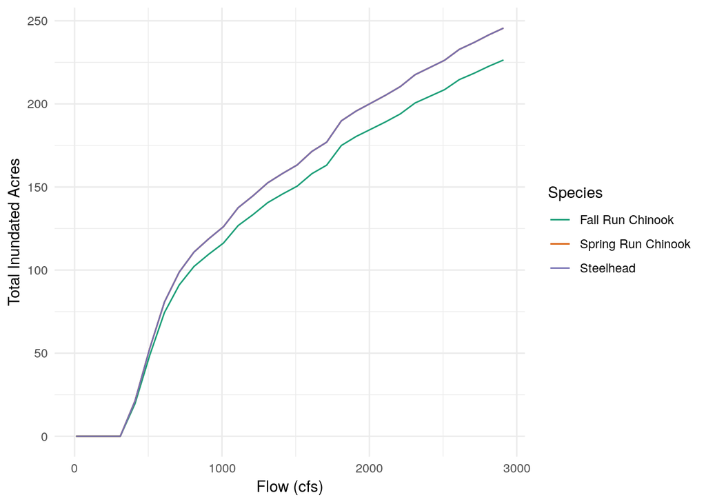